# Analysis of the Iris Dataset in R

DTS 211 - Introduction to R Programming

# Introduction

The Iris dataset records sepal length, sepal width, petal length and petal width for 150 flowers. The measurements are in centimetres. This project uses R to compare the three species and check how well a k-NN model can predict them.

# Data import and exploration

```r
head(iris)
```

```
##   Sepal.Length Sepal.Width Petal.Length Petal.Width Species
## 1          5.1         3.5          1.4         0.2  setosa
## 2          4.9         3.0          1.4         0.2  setosa
## 3          4.7         3.2          1.3         0.2  setosa
## 4          4.6         3.1          1.5         0.2  setosa
## 5          5.0         3.6          1.4         0.2  setosa
## 6          5.4         3.9          1.7         0.4  setosa
```

```r
str(iris)
```

```
## 'data.frame':    150 obs. of  5 variables:
##  $ Sepal.Length: num  5.1 4.9 4.7 4.6 5 5.4 4.6 5 4.4 4.9 ...
##  $ Sepal.Width : num  3.5 3 3.2 3.1 3.6 3.9 3.4 3.4 2.9 3.1 ...
##  $ Petal.Length: num  1.4 1.4 1.3 1.5 1.4 1.7 1.4 1.5 1.4 1.5 ...
##  $ Petal.Width : num  0.2 0.2 0.2 0.2 0.2 0.4 0.3 0.2 0.2 0.1 ...
##  $ Species     : Factor w/ 3 levels "setosa","versicolor",..: 1 1 1 1 1 1 1 1 1 1 ...
```

```r
summary(iris)
```

```
##   Sepal.Length    Sepal.Width     Petal.Length    Petal.Width
##  Min.   :4.300   Min.   :2.000   Min.   :1.000   Min.   :0.100
##  1st Qu.:5.100   1st Qu.:2.800   1st Qu.:1.600   1st Qu.:0.300
##  Median :5.800   Median :3.000   Median :4.350   Median :1.300
##  Mean   :5.843   Mean   :3.057   Mean   :3.758   Mean   :1.199
##  3rd Qu.:6.400   3rd Qu.:3.300   3rd Qu.:5.100   3rd Qu.:1.800
##  Max.   :7.900   Max.   :4.400   Max.   :6.900   Max.   :2.500
##        Species
##  setosa    :50
##  versicolor:50
##  virginica :50
##
##
##
```

```r
colSums(is.na(iris))
```

```
## Sepal.Length  Sepal.Width Petal.Length  Petal.Width      Species
##            0            0            0            0            0
```

```r
sum(duplicated(iris))
```

```
## [1] 1
```

```r
table(iris$Species)
```

```
##
##     setosa versicolor  virginica
##         50         50         50
```

There are 50 flowers from each species and no missing values. One row is repeated. It is kept because two flowers can share the same measurements when the values are rounded to one decimal place.

# Visualisations

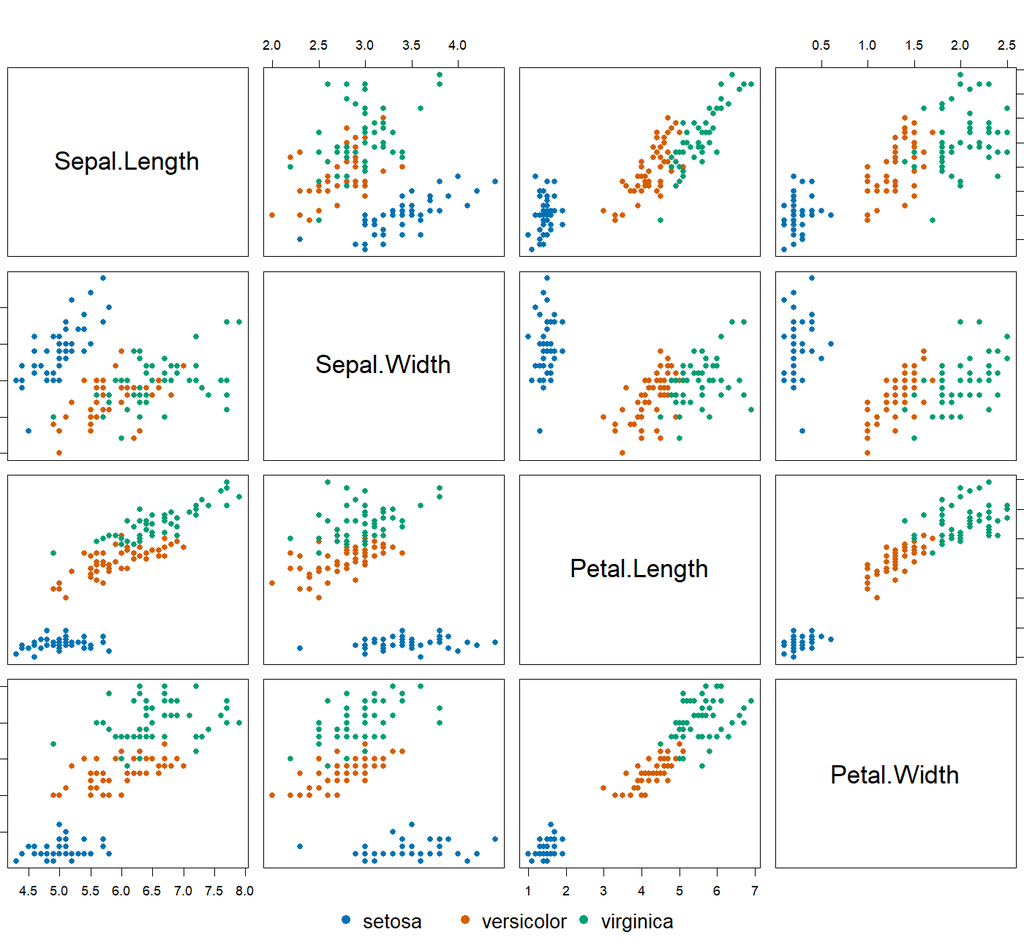

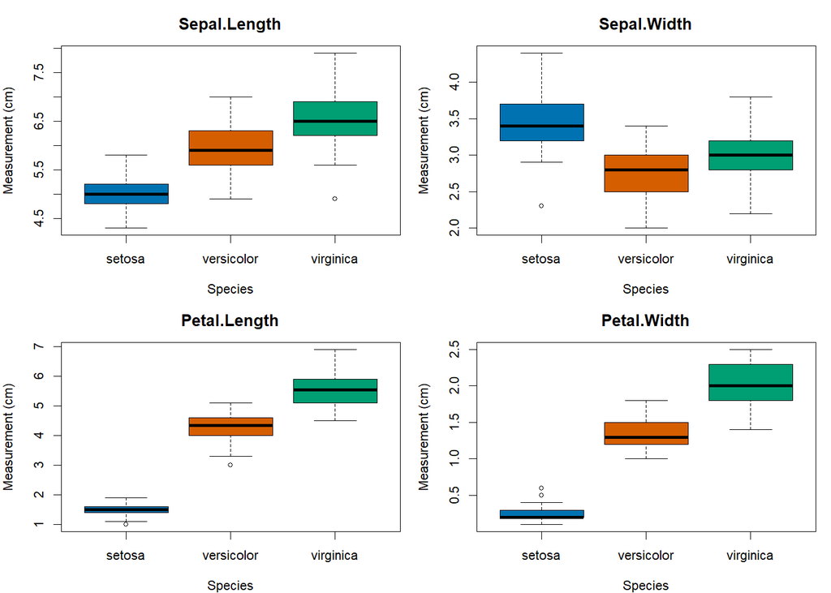

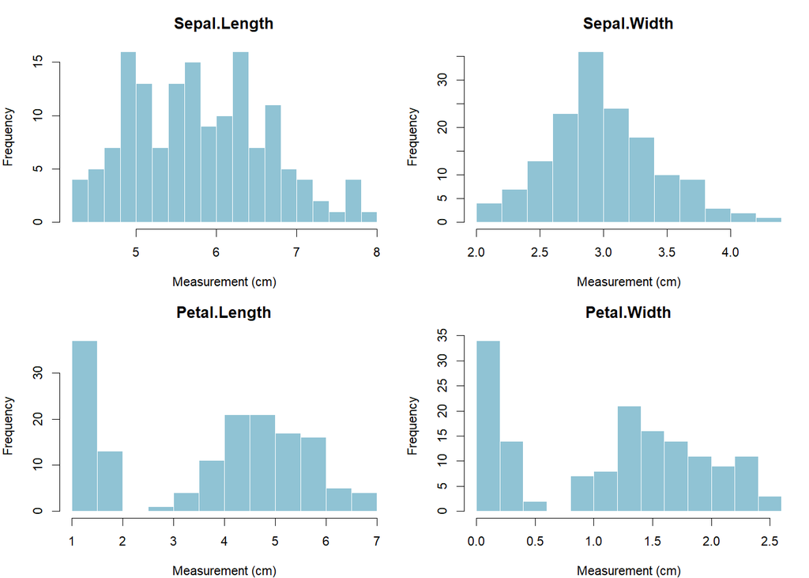

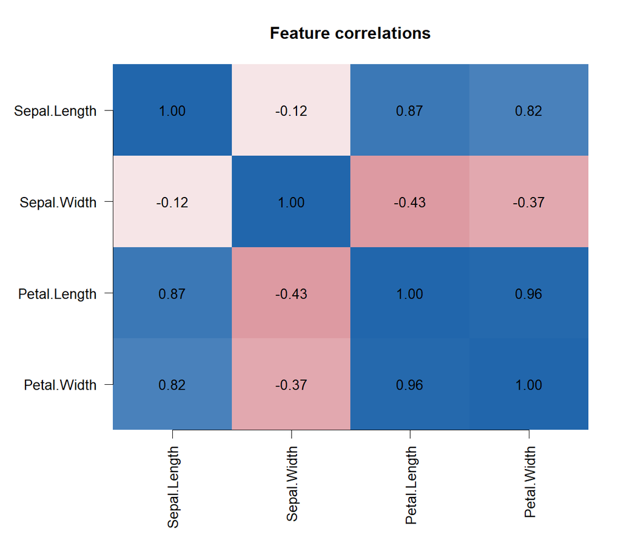

Setosa stands out in the petal plots, while versicolor and virginica overlap. Their median petal lengths are 1.50, 4.35 and 5.55 cm, respectively. Setosa has the widest sepals. Petal length and petal width tend to increase together, with a correlation of about 0.963 across all 150 flowers.

# Statistical summary

```r
knitr::kable(stats, digits=3)
```

|  | Feature | Mean | Median | SD | Min | Max |
| --- | --- | --- | --- | --- | --- | --- |
| Sepal.Length | Sepal.Length | 5.843 | 5.80 | 0.828 | 4.3 | 7.9 |
| Sepal.Width | Sepal.Width | 3.057 | 3.00 | 0.436 | 2.0 | 4.4 |
| Petal.Length | Petal.Length | 3.758 | 4.35 | 1.765 | 1.0 | 6.9 |
| Petal.Width | Petal.Width | 1.199 | 1.30 | 0.762 | 0.1 | 2.5 |

```r
by_species
```

```
##      Species Sepal.Length.mean Sepal.Length.median Sepal.Length.sd
## 1     setosa         5.0060000           5.0000000       0.3524897
## 2 versicolor         5.9360000           5.9000000       0.5161711
## 3  virginica         6.5880000           6.5000000       0.6358796
##   Sepal.Width.mean Sepal.Width.median Sepal.Width.sd Petal.Length.mean
## 1        3.4280000          3.4000000      0.3790644         1.4620000
## 2        2.7700000          2.8000000      0.3137983         4.2600000
## 3        2.9740000          3.0000000      0.3224966         5.5520000
##   Petal.Length.median Petal.Length.sd Petal.Width.mean Petal.Width.median
## 1           1.5000000       0.1736640        0.2460000          0.2000000
## 2           4.3500000       0.4699110        1.3260000          1.3000000
## 3           5.5500000       0.5518947        2.0260000          2.0000000
##   Petal.Width.sd
## 1      0.1053856
## 2      0.1977527
## 3      0.2746501
```

The table uses the sample standard deviation, calculated with n - 1 in the denominator. Petal measurements vary more relative to their means than sepal measurements do. Much of this difference comes from the gap between species. For petal length, the mean is 3.758 cm and the median is 4.350 cm. The small setosa petals pull the overall mean down.

# Methodology and classification

Using set.seed(42), the data are split into 35 training flowers and 15 test flowers for each species. The training means and standard deviations are used to scale both sets, so the test data do not affect this step. The model uses k = 5, chosen before looking at the test results. It predicts the species that appears most often among the five nearest training flowers, using Euclidean distance.

```r
k
```

```
## [1] 5
```

```r
nrow(train)
```

```
## [1] 105
```

```r
nrow(test)
```

```
## [1] 45
```

```r
accuracy
```

```
## [1] 0.9333333
```

```r
cm
```

```
##             Predicted
## Actual       setosa versicolor virginica
##   setosa         15          0         0
##   versicolor      0         14         1
##   virginica       0          2        13
```

Test accuracy is 93.3% (42 of 45 flowers). All 15 setosa test flowers are classified correctly. One versicolor flower is labelled as virginica, and two virginica flowers are labelled as versicolor. These are the species that overlap in the plots.

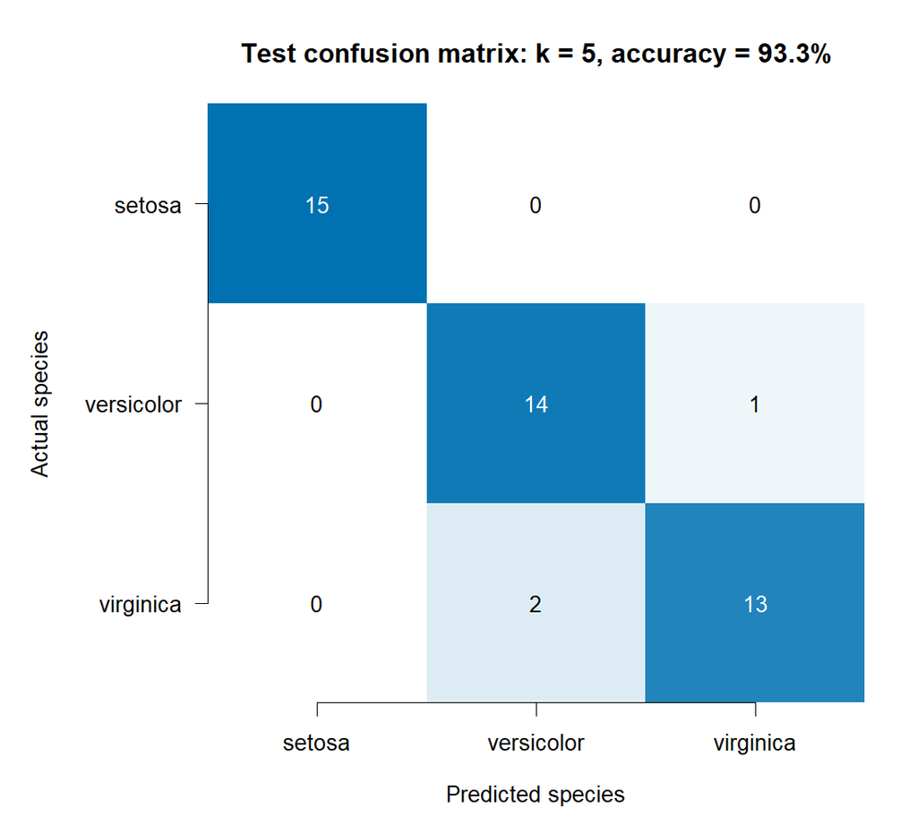

# Conclusion

The petal measurements give the clearest differences between species. With k = 5, the model gets 42 out of 45 test flowers right, or 93.3%. The result is encouraging, but the test set is small: one extra error would change the accuracy by 2.22 percentage points. Repeating the split and comparing k-NN with another classifier would help check how stable the result is. A further question is whether petal length and petal width alone would be enough.

# R code

```r
# DTS 211 - Analysis of the Iris Dataset in R
# Run from this folder: Rscript iris_analysis.R
suppressPackageStartupMessages(library(class))
dir.create("results", showWarnings=FALSE)
data(iris, package="datasets")
print(head(iris)); str(iris); print(summary(iris))
cat("Missing values:", sum(is.na(iris)), "\nDuplicates:", sum(duplicated(iris)), "\n")
print(table(iris$Species))
x <- iris[,1:4]
stats <- data.frame(Feature=names(x), Mean=sapply(x,mean), Median=sapply(x,median), SD=sapply(x,sd), Min=sapply(x,min), Max=sapply(x,max))
print(stats)
write.csv(stats,"results/summary.csv",row.names=FALSE)
by_species <- aggregate(x, list(Species=iris$Species), function(z)c(mean=mean(z),median=median(z),sd=sd(z)))
print(by_species)
write.csv(by_species,"results/summary_by_species.csv",row.names=FALSE)
cols <- c("#0072B2", "#D55E00", "#009E73")
png("results/pairplot.png",width=1400,height=1300,res=160)
pairs(x,col=cols[iris$Species],pch=19,oma=c(5,0,4,0))
mtext("Iris scatterplot matrix (cm)",side=3,outer=TRUE,line=1)
par(fig=c(0,1,0,0.065),mar=c(0,0,0,0),new=TRUE);plot.new()
legend("center",legend=levels(iris$Species),col=cols,pch=19,horiz=TRUE,bty="n");dev.off()
png("results/boxplots.png",width=1400,height=1000,res=160)
par(mfrow=c(2,2),mar=c(4,4,3,1))
for(n in names(x))boxplot(iris[[n]]~iris$Species,col=cols,main=n,xlab="Species",ylab="Measurement (cm)")
dev.off()
png("results/histograms.png",width=1400,height=1000,res=160)
par(mfrow=c(2,2),mar=c(4,4,3,1))
for(n in names(x))hist(x[[n]],breaks=15,col="#90C3D4",border="white",main=n,xlab="Measurement (cm)")
dev.off()
png("results/correlation.png",width=1200,height=1050,res=160)
par(mar=c(7,7,4,2));cr<-cor(x)
image(1:4,1:4,t(cr[4:1,]),col=colorRampPalette(c("#B2182B","white","#2166AC"))(100),zlim=c(-1,1),axes=FALSE,xlab="",ylab="",main="Feature correlations")
axis(1,1:4,labels=colnames(cr),las=2);axis(2,1:4,labels=rownames(cr)[4:1],las=2)
for(i in 1:4)for(j in 1:4)text(i,j,sprintf("%.2f",cr[5-j,i]))
dev.off()
# Stratified 70/30 split: 35 training and 15 test flowers per species.
set.seed(42)
train_idx <- sort(unlist(lapply(split(seq_len(nrow(iris)),iris$Species),function(ids)sample(ids,35))))
train <- x[train_idx,]; test <- x[-train_idx,]
y_train<-iris$Species[train_idx];y_test<-iris$Species[-train_idx]
# Fit standardisation on training data only.
center<-sapply(train,mean);spread<-sapply(train,sd)
train_z<-scale(train,center=center,scale=spread)
test_z<-scale(test,center=center,scale=spread)
# k is specified before examining the test set.
k<-5L
set.seed(42)
pred<-knn(train_z,test_z,y_train,k=k)
cm<-table(Actual=y_test,Predicted=pred)
accuracy<-mean(pred==y_test)
cat("\nk =",k," Test accuracy =",accuracy,"\n");print(cm)
write.csv(as.data.frame.matrix(cm),"results/confusion_matrix.csv")
write.csv(data.frame(k=k,accuracy=accuracy,train_n=nrow(train),test_n=nrow(test)),"results/metrics.csv",row.names=FALSE)
write.csv(data.frame(row=seq_len(nrow(iris)),set=ifelse(seq_len(nrow(iris))%in%train_idx,"train","test")),"results/split.csv",row.names=FALSE)
png("results/model.png",width=1100,height=1000,res=160)
par(mar=c(5,8,4,2));image(1:3,1:3,t(cm[3:1,]),col=colorRampPalette(c("white","#0072B2"))(100),axes=FALSE,xlab="Predicted species",ylab="",main=sprintf("Test confusion matrix: k = %d, accuracy = %.1f%%",k,100*accuracy))
axis(1,1:3,labels=colnames(cm));axis(2,1:3,labels=rownames(cm)[3:1],las=2)
mtext("Actual species",side=2,line=6)
for(i in 1:3)for(j in 1:3)text(i,j,cm[4-j,i],col=if(cm[4-j,i]>7)"white" else "black")
dev.off()
capture.output(sessionInfo(),file="results/sessionInfo.txt")
```

# Software and data

Data: built-in R datasets::iris; model: class::knn.